# 数据分析岗位需求调查研究

*此处以拉勾网站\为例：https://www.lagou.com*  
数据来源于网络

### 1.导入数据-pandas

```python
import pandas as pd  #数据分析
import matplotlib.pyplot as plt
import seaborn as sns   #绘图
```

```python
CSV_FILE_PATH = 'D:\\University\\jobs.csv' #导入数据文件
df = pd.read_csv(CSV_FILE_PATH,encoding='utf-8',index_col=0)
print(df.head(5))#打印出前五行查看
```

```
   positionId         positionName  companyId companyFullName  \
0     7705703         高级/资深业务数据分析师        147    北京拉勾网络技术有限公司
1     7714883         02326I-数据分析师     140014  中国平安人寿保险股份有限公司
2     7672464  02324X-用户运营（数据分析方向）     140014  中国平安人寿保险股份有限公司
3     7049497               游戏数据分析       1880  北京达佳互联信息技术有限公司
4     7873318                数据分析师         62    北京字节跳动科技有限公司

  companyShortName companySize industryField financeStage  \
0              拉勾网   500-2000人          企业服务        D轮及以上
1             平安人寿     2000人以上            金融         上市公司
2             平安人寿     2000人以上            金融         上市公司
3               快手     2000人以上         文娱丨内容        D轮及以上
4             字节跳动     2000人以上         文娱丨内容           C轮

                       companyLabelList  firstType  ... gradeDescription  \
```

[output cut: 21 more lines]

```python
#查看数据属性
df.info()
```

```
<class 'pandas.core.frame.DataFrame'>
Int64Index: 450 entries, 0 to 14
Data columns (total 61 columns):
positionId               450 non-null int64
positionName             450 non-null object
companyId                450 non-null int64
companyFullName          450 non-null object
companyShortName         450 non-null object
companySize              450 non-null object
industryField            450 non-null object
financeStage             450 non-null object
companyLabelList         450 non-null object
firstType                450 non-null object
secondType               450 non-null object
thirdType                450 non-null object
skillLables              450 non-null object
positionLables           450 non-null object
industryLables           450 non-null object
createTime               450 non-null object
formatCreateTime         450 non-null object
city                     450 non-null object
district                 447 non-null object
businessZones            198 non-null object
salary                   450 non-null object
salaryMonth              450 non-null int64
workYear                 450 non-null object
jobNature                450 non-null object
education                450 non-null object
positionAdvantage        450 non-null object
imState                  450 non-null object
lastLogin                450 non-null object
publisherId              450 non-null int64
approve                  450 non-null int64
subwayline               380 non-null object
stationname              380 non-null object
linestaion               380 non-null object
latitude                 447 non-null float64
longitude                447 non-null float64
distance                 0 non-null float64
hitags                   50 non-null object
```

[output cut: 11 more lines]

```
pcShow                   450 non-null int64
appShow                  450 non-null int64
deliver                  450 non-null int64
gradeDescription         0 non-null float64
promotionScoreExplain    0 non-null float64
isHotHire                450 non-null int64
count                    450 non-null int64
aggregatePositionIds     450 non-null object
promotionType            0 non-null float64
is51Job                  450 non-null bool
detailRecall             450 non-null bool
famousCompany            450 non-null bool
hunterJob                450 non-null bool
dtypes: bool(4), float64(11), int64(16), object(30)
memory usage: 205.7+ KB
```

```python
df.describe()
```

[output not shown]

8 rows × 28 columns

```python
df.head()
```

|  | positionId | positionName | companyId | companyFullName | companyShortName | companySize | industryField | financeStage | companyLabelList | firstType | ... | gradeDescription | promotionScoreExplain | isHotHire | count | aggregatePositionIds | promotionType | is51Job | detailRecall | famousCompany | hunterJob |
| --- | --- | --- | --- | --- | --- | --- | --- | --- | --- | --- | --- | --- | --- | --- | --- | --- | --- | --- | --- | --- | --- |
| 0 | 7705703 | 高级/资深业务数据分析师 | 147 | 北京拉勾网络技术有限公司 | 拉勾网 | 500-2000人 | 企业服务 | D轮及以上 | ['五险一金', '弹性工作', '带薪年假', '免费两餐'] | 开发\|测试\|运维类 | ... | NaN | NaN | 0 | 0 | [] | NaN | False | False | True | False |
| 1 | 7714883 | 02326I-数据分析师 | 140014 | 中国平安人寿保险股份有限公司 | 平安人寿 | 2000人以上 | 金融 | 上市公司 | ['绩效奖金', '带薪年假', '定期体检', '节日礼物'] | 产品\|需求\|项目类 | ... | NaN | NaN | 0 | 0 | [] | NaN | False | False | True | False |
| 2 | 7672464 | 02324X-用户运营（数据分析方向） | 140014 | 中国平安人寿保险股份有限公司 | 平安人寿 | 2000人以上 | 金融 | 上市公司 | ['绩效奖金', '带薪年假', '定期体检', '节日礼物'] | 运营\|编辑\|客服类 | ... | NaN | NaN | 0 | 0 | [] | NaN | False | False | True | False |
| 3 | 7049497 | 游戏数据分析 | 1880 | 北京达佳互联信息技术有限公司 | 快手 | 2000人以上 | 文娱丨内容 | D轮及以上 | ['股票期权', '弹性工作', '定期体检', '岗位晋升'] | 产品\|需求\|项目类 | ... | NaN | NaN | 0 | 0 | [] | NaN | False | False | True | False |
| 4 | 7873318 | 数据分析师 | 62 | 北京字节跳动科技有限公司 | 字节跳动 | 2000人以上 | 文娱丨内容 | C轮 | ['扁平管理', '弹性工作', '大厨定制三餐', '就近租房补贴'] | 产品\|需求\|项目类 | ... | NaN | NaN | 0 | 0 | [] | NaN | False | False | True | False |

5 rows × 61 columns

### 2.数据清洗

```python
import numpy as np
```

我们选出对于即将进行分析有用的数据属性，如：岗位名称、招聘公司、公司规模、领域、融资阶段、职位福利、城市、薪资、工作经验、学历、位置信息、是否为校招、是否为知名企业。

```python
new_col = ['positionName','companyShortName','companySize',
           'industryField','financeStage','companyLabelList',
           'firstType','skillLables','positionLables','city',
          'salary','workYear','education','latitude','longitude',
          'isSchoolJob','famousCompany']
position = df[new_col]#只保留我们需要的信息
```

```python
position.head()
```

|  | positionName | companyShortName | companySize | industryField | financeStage | companyLabelList | firstType | skillLables | positionLables | city | salary | workYear | education | latitude | longitude | isSchoolJob | famousCompany |
| --- | --- | --- | --- | --- | --- | --- | --- | --- | --- | --- | --- | --- | --- | --- | --- | --- | --- |
| 0 | 高级/资深业务数据分析师 | 拉勾网 | 500-2000人 | 企业服务 | D轮及以上 | ['五险一金', '弹性工作', '带薪年假', '免费两餐'] | 开发\|测试\|运维类 | ['Spark', 'python', 'R', '建业务分析模型'] | ['教育', 'Spark', 'python', 'R', '建业务分析模型'] | 北京 | 20k-40k | 3-5年 | 本科 | 39.982128 | 116.307747 | 0 | True |
| 1 | 02326I-数据分析师 | 平安人寿 | 2000人以上 | 金融 | 上市公司 | ['绩效奖金', '带薪年假', '定期体检', '节日礼物'] | 产品\|需求\|项目类 | ['数据库', '商业', 'BI', '数据分析'] | ['保险', '互联网金融', '数据库', '商业', 'BI', '数据分析'] | 上海 | 12k-22k | 1-3年 | 本科 | 31.238157 | 121.666906 | 0 | True |
| 2 | 02324X-用户运营（数据分析方向） | 平安人寿 | 2000人以上 | 金融 | 上市公司 | ['绩效奖金', '带薪年假', '定期体检', '节日礼物'] | 运营\|编辑\|客服类 | [] | ['保险', '互联网金融'] | 上海 | 10k-20k | 1-3年 | 本科 | 31.238157 | 121.666906 | 0 | True |
| 3 | 游戏数据分析 | 快手 | 2000人以上 | 文娱丨内容 | D轮及以上 | ['股票期权', '弹性工作', '定期体检', '岗位晋升'] | 产品\|需求\|项目类 | [] | [] | 北京 | 15k-30k | 3-5年 | 本科 | 40.053389 | 116.298440 | 0 | True |
| 4 | 数据分析师 | 字节跳动 | 2000人以上 | 文娱丨内容 | C轮 | ['扁平管理', '弹性工作', '大厨定制三餐', '就近租房补贴'] | 产品\|需求\|项目类 | [] | ['数据分析'] | 北京 | 15k-30k | 1-3年 | 本科 | 39.971819 | 116.328708 | 0 | True |

```python
#缺失值检测函数
def null_value_check(data):
    '''输入：pandas数组'''
    '''输出：每一列的缺失值情况'''
    for i in data.columns:
        print(i,'列缺失值个数为：',data[i].isnull().sum())
```

```python
#检查一下有没有缺失值
null_value_check(position)
```

```
positionName 列缺失值个数为： 0
companyShortName 列缺失值个数为： 0
companySize 列缺失值个数为： 0
industryField 列缺失值个数为： 0
financeStage 列缺失值个数为： 0
companyLabelList 列缺失值个数为： 0
firstType 列缺失值个数为： 0
skillLables 列缺失值个数为： 0
positionLables 列缺失值个数为： 0
city 列缺失值个数为： 0
salary 列缺失值个数为： 0
workYear 列缺失值个数为： 0
education 列缺失值个数为： 0
latitude 列缺失值个数为： 3
longitude 列缺失值个数为： 3
isSchoolJob 列缺失值个数为： 0
famousCompany 列缺失值个数为： 0
```

对于缺失值的处理方式通常有：  
1.删除这些变量是缺失值(unknown)的行；  
2.如果预计该变量对于学习模型效果影响不大，可以对unknown值赋众数，这里认为变量都对学习模型有较大影响，不采取此法；  
3.可以使用数据完整的行作为训练集，以此来预测缺失值。

但我们只是对数据进行分析，并不对数据进行建模，且缺失值不多，对其他行没有影响。在这里我们直接删掉有缺失值的行即可。

```python
#删除缺失值
#axis=0: 删除包含缺失值的行
#how=‘any’ :只要有缺失值出现，就删除该行
#inplace=True在原数据上操作
position.dropna(axis=0, how='any', thresh=None, subset=None, inplace=True)
```

```python
position
```

|  | positionName | companyShortName | companySize | industryField | financeStage | companyLabelList | firstType | skillLables | positionLables | city | salary | workYear | education | latitude | longitude | isSchoolJob | famousCompany |
| --- | --- | --- | --- | --- | --- | --- | --- | --- | --- | --- | --- | --- | --- | --- | --- | --- | --- |
| 0 | 高级/资深业务数据分析师 | 拉勾网 | 500-2000人 | 企业服务 | D轮及以上 | ['五险一金', '弹性工作', '带薪年假', '免费两餐'] | 开发\|测试\|运维类 | ['Spark', 'python', 'R', '建业务分析模型'] | ['教育', 'Spark', 'python', 'R', '建业务分析模型'] | 北京 | 20k-40k | 3-5年 | 本科 | 39.982128 | 116.307747 | 0 | True |
| 1 | 02326I-数据分析师 | 平安人寿 | 2000人以上 | 金融 | 上市公司 | ['绩效奖金', '带薪年假', '定期体检', '节日礼物'] | 产品\|需求\|项目类 | ['数据库', '商业', 'BI', '数据分析'] | ['保险', '互联网金融', '数据库', '商业', 'BI', '数据分析'] | 上海 | 12k-22k | 1-3年 | 本科 | 31.238157 | 121.666906 | 0 | True |
| 2 | 02324X-用户运营（数据分析方向） | 平安人寿 | 2000人以上 | 金融 | 上市公司 | ['绩效奖金', '带薪年假', '定期体检', '节日礼物'] | 运营\|编辑\|客服类 | [] | ['保险', '互联网金融'] | 上海 | 10k-20k | 1-3年 | 本科 | 31.238157 | 121.666906 | 0 | True |
| 3 | 游戏数据分析 | 快手 | 2000人以上 | 文娱丨内容 | D轮及以上 | ['股票期权', '弹性工作', '定期体检', '岗位晋升'] | 产品\|需求\|项目类 | [] | [] | 北京 | 15k-30k | 3-5年 | 本科 | 40.053389 | 116.298440 | 0 | True |
| 4 | 数据分析师 | 字节跳动 | 2000人以上 | 文娱丨内容 | C轮 | ['扁平管理', '弹性工作', '大厨定制三餐', '就近租房补贴'] | 产品\|需求\|项目类 | [] | ['数据分析'] | 北京 | 15k-30k | 1-3年 | 本科 | 39.971819 | 116.328708 | 0 | True |
| ... | ... | ... | ... | ... | ... | ... | ... | ... | ... | ... | ... | ... | ... | ... | ... | ... | ... |
| 10 | 数据分析专家 | 触宝 | 500-2000人 | 移动互联网,数据服务 | 上市公司 | ['美股上市', '行业独角兽', '年底双薪', '绩效奖金'] | 产品\|需求\|项目类 | ['增长黑客', '数据分析', '商业'] | ['增长黑客', '数据分析', '商业'] | 上海 | 30k-60k | 5-10年 | 本科 | 31.159507 | 121.354889 | 0 | False |
| 11 | 数据分析师(J10697) | 伴鱼口语 | 2000人以上 | 移动互联网 | C轮 | ['带薪年假', '交通补助', '五险一金', '住宿补贴'] | 开发\|测试\|运维类 | ['数据分析'] | ['数据分析'] | 北京 | 20k-40k | 3-5年 | 本科 | 39.970753 | 116.378536 | 0 | False |
| 12 | 高级数据分析师 | 极光 | 500-2000人 | 企业服务 | 上市公司 | ['五险一金', '文体活动', '团建旅游', '美味晚餐'] | 产品\|需求\|项目类 | ['SQL', '数据库', '商业', '数据分析'] | ['SQL', '数据库', '商业', '数据分析'] | 深圳 | 25k-35k | 3-5年 | 本科 | 22.550224 | 113.908469 | 0 | True |
| 13 | 游戏数据分析师 | 奇客创想 | 150-500人 | 移动互联网,游戏 | 不需要融资 | ['五险一金', '带薪年假', '年底双薪', '绩效奖金'] | 运营\|编辑\|客服类 | ['数据分析', '活动运营', '游戏运营', '市场'] | ['游戏', '数据分析', '活动运营', '游戏运营', '市场'] | 北京 | 12k-16k | 1-3年 | 本科 | 39.972134 | 116.329519 | 0 | False |
| 14 | 数据分析（广告优化） (MJ002029) | SHEIN | 2000人以上 | 电商,移动互联网 | C轮 | [] | 开发\|测试\|运维类 | ['数据分析'] | ['数据分析'] | 南京 | 5k-8k | 1-3年 | 本科 | 31.974269 | 118.755582 | 0 | False |

447 rows × 17 columns

### 3.数据分析

```python
position.columns #查看属性
```

```
Index(['positionName', 'companyShortName', 'companySize', 'industryField',
       'financeStage', 'companyLabelList', 'firstType', 'skillLables',
       'positionLables', 'city', 'salary', 'workYear', 'education', 'latitude',
       'longitude', 'isSchoolJob', 'famousCompany'],
      dtype='object')
```

**（1）招聘公司统计-到底是哪些公司招聘数据分析岗位多？**

```python
#选取排名前二十的公司进行分析
company = position['companyShortName'].value_counts().iloc[:20,]
company
```

```
字节跳动      31
美团        12
拉勾网        8
平安人寿       6
储慧国际咨询     5
平安金服       5
盛业恒泰投资     5
小赢科技       4
爱奇艺        4
贝壳         4
快手         4
浙江盘石       3
同花顺        3
京东数字科技     3
途虎养车网      3
优车库        3
跟谁学        3
得物App      3
易观         3
新明珠集团      3
Name: companyShortName, dtype: int64
```

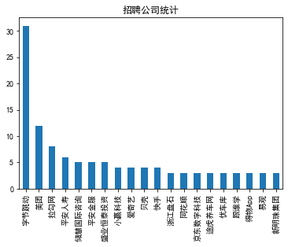

```python
#导包
import matplotlib.pyplot as plt
plt.rcParams['font.sans-serif'] = ['SimHei']    # 指定默认字体：解决plot不能显示中文问题
company.plot.bar()
plt.title('招聘公司统计')
```

通过图表我们可以看出，字节招数据分析的岗位比较多，其次是美团、拉勾网等。  
接下来我们分析一下公司规模。

```python
company_size = position['companySize'].value_counts()
company_size
```

```
2000人以上      157
500-2000人     99
150-500人      94
50-150人       73
15-50人        22
少于15人          2
Name: companySize, dtype: int64
```

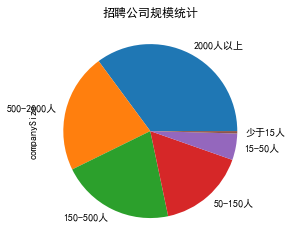

```python
company_size.plot.pie()
plt.title('招聘公司规模统计')
```

**（2）地理位置统计-哪些城市对数据分析岗位需求大？**

```python
city_need = position['city'].value_counts()
city_need
```

```
北京      177
上海       76
深圳       66
广州       43
杭州       32
成都       21
重庆        6
南京        3
佛山        3
武汉        3
郑州        2
长沙        2
宁波        2
贵阳        2
宿迁        1
大连        1
西安        1
福州        1
东莞        1
厦门        1
太原        1
青岛        1
乌鲁木齐      1
Name: city, dtype: int64
```

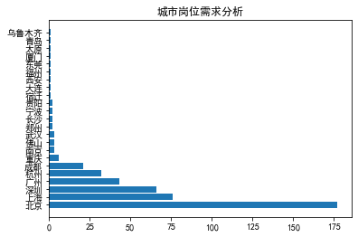

```python
# 这两行代码解决中文显示的问题
plt.rcParams['font.sans-serif'] = ['SimHei']
plt.rcParams['axes.unicode_minus'] = False

city = city_need.index
number = city_need.values

plt.barh(city, number) # 横放条形图函数 barh
plt.title('城市岗位需求分析')

plt.show()
```

用pyecharts进行绘制图像

```python
city,number
```

```
(Index(['北京', '上海', '深圳', '广州', '杭州', '成都', '重庆', '南京', '佛山', '武汉', '郑州', '长沙',
        '宁波', '贵阳', '宿迁', '大连', '西安', '福州', '东莞', '厦门', '太原', '青岛', '乌鲁木齐'],
       dtype='object'),
 array([177,  76,  66,  43,  32,  21,   6,   3,   3,   3,   2,   2,   2,
          2,   1,   1,   1,   1,   1,   1,   1,   1,   1], dtype=int64))
```

```python
import pyecharts.charts as pyec
x=['北京', '上海', '深圳', '广州', '杭州', '成都', '重庆', '南京', '佛山', '武汉', '郑州', '长沙',
        '宁波', '贵阳', '宿迁', '大连', '西安', '福州', '东莞', '厦门', '太原', '青岛', '乌鲁木齐']
y=[177,  76,  66,  43,  32,  21,   6,   3,   3,   3,   2,   2,   2,
          2,   1,   1,   1,   1,   1,   1,   1,   1,   1]

bar=pyec.Bar()
bar.add_xaxis(x)
bar.add_yaxis('数量',yaxis_data=y)
bar.render_notebook()
```

从图表我们可以得知，还是北上广深这类一线城市对于数据分析岗位需求很大，而其他新一线或者二线省会对该岗位需求并不大。

```python
position.head()
```

|  | positionName | companyShortName | companySize | industryField | financeStage | companyLabelList | firstType | skillLables | positionLables | city | salary | workYear | education | latitude | longitude | isSchoolJob | famousCompany |
| --- | --- | --- | --- | --- | --- | --- | --- | --- | --- | --- | --- | --- | --- | --- | --- | --- | --- |
| 0 | 高级/资深业务数据分析师 | 拉勾网 | 500-2000人 | 企业服务 | D轮及以上 | ['五险一金', '弹性工作', '带薪年假', '免费两餐'] | 开发\|测试\|运维类 | ['Spark', 'python', 'R', '建业务分析模型'] | ['教育', 'Spark', 'python', 'R', '建业务分析模型'] | 北京 | 20k-40k | 3-5年 | 本科 | 39.982128 | 116.307747 | 0 | True |
| 1 | 02326I-数据分析师 | 平安人寿 | 2000人以上 | 金融 | 上市公司 | ['绩效奖金', '带薪年假', '定期体检', '节日礼物'] | 产品\|需求\|项目类 | ['数据库', '商业', 'BI', '数据分析'] | ['保险', '互联网金融', '数据库', '商业', 'BI', '数据分析'] | 上海 | 12k-22k | 1-3年 | 本科 | 31.238157 | 121.666906 | 0 | True |
| 2 | 02324X-用户运营（数据分析方向） | 平安人寿 | 2000人以上 | 金融 | 上市公司 | ['绩效奖金', '带薪年假', '定期体检', '节日礼物'] | 运营\|编辑\|客服类 | [] | ['保险', '互联网金融'] | 上海 | 10k-20k | 1-3年 | 本科 | 31.238157 | 121.666906 | 0 | True |
| 3 | 游戏数据分析 | 快手 | 2000人以上 | 文娱丨内容 | D轮及以上 | ['股票期权', '弹性工作', '定期体检', '岗位晋升'] | 产品\|需求\|项目类 | [] | [] | 北京 | 15k-30k | 3-5年 | 本科 | 40.053389 | 116.298440 | 0 | True |
| 4 | 数据分析师 | 字节跳动 | 2000人以上 | 文娱丨内容 | C轮 | ['扁平管理', '弹性工作', '大厨定制三餐', '就近租房补贴'] | 产品\|需求\|项目类 | [] | ['数据分析'] | 北京 | 15k-30k | 1-3年 | 本科 | 39.971819 | 116.328708 | 0 | True |

**（3）薪资水平统计-该岗位一般处于什么薪资水平？**

首先我们对表格里的薪资水平格式进行修改。因为表格里以范围的形式显示，这里我们取范围中值进行分析。

```python
def salary_count(x):
    x_min,x_max = x.split('-')  #获取-两边的最大最小值
    x_min = int(x_min.replace('k','000'))
    x_max = int(x_max.replace('k','000')) #截取字符串，把k改成000，将字符串转化为数字
    return np.mean([x_min,x_max])
```

```python
#选取北上广深四个城市进行岗位平均工资分析

city = ['北京','上海','广州','深圳']

salary1 = position[position['city']=='北京']
salary2 = position[position['city']=='上海']
salary3 = position[position['city']=='广州']
salary4 = position[position['city']=='深圳']
```

```python
salary1 = np.array(salary1['salary'].apply(salary_count)).mean()
salary2 = np.array(salary2['salary'].apply(salary_count)).mean()
salary3 = np.array(salary3['salary'].apply(salary_count)).mean()
salary4 = np.array(salary4['salary'].apply(salary_count)).mean()
```

```python
salary = [salary1,salary2,salary3,salary4]
salary
```

```
[23016.949152542373, 20723.684210526317, 15523.255813953489, 18060.60606060606]
```

```python
bar=pyec.Bar()
bar.add_xaxis(city)
bar.add_yaxis('平均工资',salary)
bar.render_notebook()
```

从图表中我们可以看出，北京行业平均工资最高，达23016元，广州在 四个城市里最低，只有15523元。

**（4）学历要求统计-该岗位一般要求学历多高？**

```python
position['education'].value_counts()
```

```
本科    386
不限     31
大专     17
硕士     13
Name: education, dtype: int64
```

```python
x =  ['硕士','本科','大专','不限']
y =  [13,386,17,31]

c = (
    Pie()
    .add("", [list(z) for z in zip(x,y)])
    .set_global_opts(title_opts=opts.TitleOpts(title="岗位学历需求"))
    .set_series_opts(label_opts=opts.LabelOpts(formatter="{b}: {c}"))
)
c.render_notebook()
```

从图表中可以看出，数据分析岗位对于学历要求大多数是本科。

**（4）岗位福利一览**

```python
position['companyLabelList']
```

```
0         ['五险一金', '弹性工作', '带薪年假', '免费两餐']
1         ['绩效奖金', '带薪年假', '定期体检', '节日礼物']
2         ['绩效奖金', '带薪年假', '定期体检', '节日礼物']
3         ['股票期权', '弹性工作', '定期体检', '岗位晋升']
4     ['扁平管理', '弹性工作', '大厨定制三餐', '就近租房补贴']
                      ...
10       ['美股上市', '行业独角兽', '年底双薪', '绩效奖金']
11        ['带薪年假', '交通补助', '五险一金', '住宿补贴']
12        ['五险一金', '文体活动', '团建旅游', '美味晚餐']
13        ['五险一金', '带薪年假', '年底双薪', '绩效奖金']
14                                      []
Name: companyLabelList, Length: 447, dtype: object
```

```python
import jieba  #这里用了jieba分词
import matplotlib.pyplot as plt
from wordcloud import WordCloud
text = ' '.join(position['companyLabelList'])
cut_text = ' '.join(jieba.cut(text_c, cut_all=False, HMM=True))
```

```
Building prefix dict from the default dictionary ...
Dumping model to file cache C:\Users\安雅沛\AppData\Local\Temp\jieba.cache
Loading model cost 1.017 seconds.
Prefix dict has been built successfully.
```

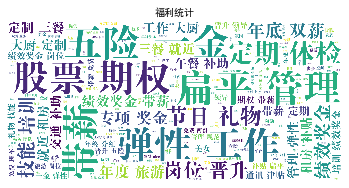

```python
font = r'C:\Windows\Fonts\FZDBSJW.TTF'
wc = WordCloud(background_color='white',  #背景设置为白色
               width=1300, height=620,
               font_path=font,
              max_font_size=150) #这里要设置字体不然显示不出来
wordcloud = wc.generate(cut_text)
plt.imshow(wordcloud)
plt.title(u"福利统计",fontsize=10)
plt.axis('off') # 不显示坐标
plt.show()
```

**（5）招聘分布一览**

```python
from pyecharts.charts import Geo
```

```python
from pyecharts import options as opts
from pyecharts.charts import Geo
from pyecharts.globals import ChartType, SymbolType

x=['北京', '上海', '深圳', '广州', '杭州', '成都', '重庆', '南京', '佛山', '武汉', '郑州', '长沙',
        '宁波', '贵阳', '宿迁', '大连', '西安', '福州', '东莞', '厦门', '太原', '青岛', '乌鲁木齐']
y=[177,  76,  66,  43,  32,  21,   6,   3,   3,   3,   2,   2,   2,
          2,   1,   1,   1,   1,   1,   1,   1,   1,   1]

# 链式调用
c = (
    Geo()
    # 加载图表模型中的中国地图
    .add_schema(maptype="china")
    # 在地图中加入点的属性
    .add("招聘",[list(z) for z in zip(x,y)])
    # 设置坐标属性
    .set_series_opts(label_opts=opts.LabelOpts(is_show=False))
    # 设置全局属性
    .set_global_opts(
        visualmap_opts=opts.VisualMapOpts(),
        title_opts=opts.TitleOpts(title="招聘地址"),
    )
)

# 在 Jupyter Notebook 中渲染图表
c.render_notebook()
```

### 实习岗位需求分析研究

*数据来源于网络-以拉勾网为例

```python
path = 'C:\\Users\\安雅沛\\Desktop\\job2.csv' #导入数据文件
df1 = pd.read_csv(path,encoding='utf-8')
print(df1.head(5))
```

```
             公司全名    公司简称       公司规模   融资阶段    区域    职位名称   工作经验 学历要求     薪资  \
0        飞友科技有限公司     飞常准  500-2000人  不需要融资   蜀山区  数据分析实习     不限   本科  2k-3k
1  北京千橡网景科技发展有限公司    人人公司    2000人以上   上市公司   朝阳区  数据分析实习  在校/应届   不限  3k-4k
2  北京千橡网景科技发展有限公司    人人公司    2000人以上   上市公司   朝阳区  数据分析实习  在校/应届   本科  2k-3k
3    上海联元智能科技有限公司  联元智能科技    50-150人     A轮   普陀区  数据分析实习  在校/应届   不限  5k-6k
4  云鹊医疗科技（上海）有限公司    云鹊医疗   150-500人  不需要融资  浦东新区  数据分析实习  在校/应届   不限  3k-4k

                   职位福利         经营范围       职位类型  \
0          周末双休、健身器材、咖啡        移动互联网  开发|测试|运维类
1     项目前景好，领导nice，弹性工作        社交,金融  产品|需求|项目类
2              领导好，管理扁平        社交,金融  开发|测试|运维类
3  五险一金 绩效奖金 弹性工作 补充公积金   移动互联网,数据服务  产品|需求|项目类
4                   成长快  医疗丨健康,移动互联网  产品|需求|项目类

                                公司福利 第二职位类型  城市
0   ['节日礼物', '年度旅游', '管理规范', '五险一金']   数据开发  合肥
1   ['五险一金', '通讯津贴', '带薪年假', '绩效奖金']   数据分析  北京
2   ['五险一金', '通讯津贴', '带薪年假', '绩效奖金']   数据开发  北京
3  ['绩效奖金', '带薪年假', '补充公积金', '年底双薪']   数据分析  上海
4    ['年底双薪', '股票期权', '带薪年假', '领导好']   数据分析  上海
```

```python
null_value_check(df1) #无缺失值
```

```
公司全名 列缺失值个数为： 0
公司简称 列缺失值个数为： 0
公司规模 列缺失值个数为： 0
融资阶段 列缺失值个数为： 0
区域 列缺失值个数为： 0
职位名称 列缺失值个数为： 0
工作经验 列缺失值个数为： 0
学历要求 列缺失值个数为： 0
薪资 列缺失值个数为： 0
职位福利 列缺失值个数为： 0
经营范围 列缺失值个数为： 0
职位类型 列缺失值个数为： 0
公司福利 列缺失值个数为： 0
第二职位类型 列缺失值个数为： 0
城市 列缺失值个数为： 0
```

```python
df1.columns #查看属性
```

```
Index(['公司全名', '公司简称', '公司规模', '融资阶段', '区域', '职位名称', '工作经验', '学历要求', '薪资',
       '职位福利', '经营范围', '职位类型', '公司福利', '第二职位类型', '城市'],
      dtype='object')
```

```python
company1 = position['companyShortName'].value_counts().iloc[:20,]
company1
```

```
字节跳动      31
美团        12
拉勾网        8
平安人寿       6
储慧国际咨询     5
平安金服       5
盛业恒泰投资     5
小赢科技       4
爱奇艺        4
贝壳         4
快手         4
浙江盘石       3
同花顺        3
京东数字科技     3
途虎养车网      3
优车库        3
跟谁学        3
得物App      3
易观         3
新明珠集团      3
Name: companyShortName, dtype: int64
```

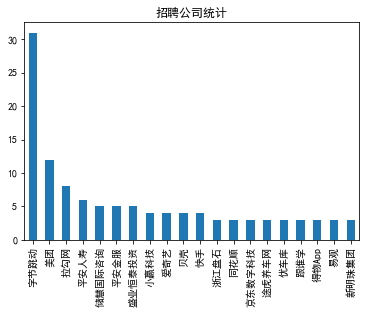

```python
plt.rcParams['font.sans-serif'] = ['SimHei']    # 指定默认字体：解决plot不能显示中文问题
company1.plot.bar()
plt.title('招聘公司统计')
```

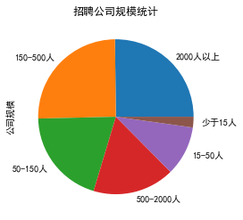

```python
company_size1 = df1['公司规模'].value_counts()
company_size1.plot.pie()
plt.title('招聘公司规模统计')
```

实习招聘的公司规模分布很均匀，看来不管是大公司还是小公司对于数据分析实习岗位都有一定的需求。

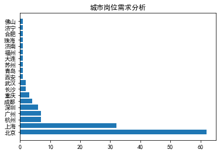

```python
city_need1 = df1['城市'].value_counts()
plt.rcParams['font.sans-serif'] = ['SimHei']
plt.rcParams['axes.unicode_minus'] = False

city1 = city_need1.index
number1 = city_need1.values

plt.barh(city1, number1) # 横放条形图函数 barh
plt.title('城市岗位需求分析')

plt.show()
```

```python
city1,number1
```

```
(Index(['北京', '上海', '杭州', '广州', '深圳', '成都', '重庆', '长沙', '武汉', '西安', '青岛', '苏州',
        '大连', '福州', '济南', '珠海', '合肥', '济宁', '佛山'],
       dtype='object'),
 array([62, 32,  7,  7,  6,  4,  3,  2,  2,  1,  1,  1,  1,  1,  1,  1,  1,
         1,  1], dtype=int64))
```

```python
x = ['北京', '上海', '杭州', '广州', '深圳', '成都', '重庆', '长沙', '武汉', '西安', '青岛', '苏州',
        '大连', '福州', '济南', '珠海', '合肥', '济宁', '佛山']
y = [62, 32,  7,  7,  6,  4,  3,  2,  2,  1,  1,  1,  1,  1,  1,  1,  1,
         1,  1]
bar=pyec.Bar()
bar.add_xaxis(x)
bar.add_yaxis('数量',yaxis_data=y)
bar.render_notebook()
```

```python
df1['学历要求'].value_counts()
```

```
本科    109
硕士     11
不限     10
大专      5
Name: 学历要求, dtype: int64
```

```python
x =  ['硕士','本科','大专','不限']
y =  [11,109,5,10]

c = (
    Pie()
    .add("", [list(z) for z in zip(x,y)])
    .set_global_opts(title_opts=opts.TitleOpts(title="岗位学历需求"))
    .set_series_opts(label_opts=opts.LabelOpts(formatter="{b}: {c}"))
)
c.render_notebook()
```

仍以本科为主。

```python
x = ['北京', '上海', '杭州', '广州', '深圳', '成都', '重庆', '长沙', '武汉', '西安', '青岛', '苏州',
        '大连', '福州', '济南', '珠海', '合肥', '济宁', '佛山']
y = [62, 32,  7,  7,  6,  4,  3,  2,  2,  1,  1,  1,  1,  1,  1,  1,  1,
         1,  1]
# 链式调用
c = (
    Geo()
    # 加载图表模型中的中国地图
    .add_schema(maptype="china")
    # 在地图中加入点的属性
    .add("招聘",[list(z) for z in zip(x,y)])
    # 设置坐标属性
    .set_series_opts(label_opts=opts.LabelOpts(is_show=False))
    # 设置全局属性
    .set_global_opts(
        visualmap_opts=opts.VisualMapOpts(),
        title_opts=opts.TitleOpts(title="招聘地址"),
    )
)

# 在 Jupyter Notebook 中渲染图表
c.render_notebook()
```